# Analisis diversidad aves robledal

## Preparar datos

- Quitamos los que no son dispersantes
- Datos desde 2010 hasta 2017

## Análisis de la diversidad por sitio

- Calculamos la diversidad por sitio para cada año
- Analizamos si existen diferencias para la diversidad entre sitios (Kruskal-Wallis) y hacemos comparaciones entre sitios (Dunn test)

| **Characteristic** | **CAM**, N = 7<sup>1</sup> | **GEN**, N = 8<sup>1</sup> | **DIL**, N = 8<sup>1</sup> | **CAN**, N = 8<sup>1</sup> |
| --- | --- | --- | --- | --- |
| Diversidad | 2.66 ± 0.05 (2.46, 2.81) | 2.82 ± 0.06 (2.66, 3.13) | 2.85 ± 0.04 (2.71, 3.07) | 1.94 ± 0.11 (1.44, 2.22) |

<sup>*1*</sup> Statistics presented: mean ± se (minimum, maximum)

### Analisis ANOVA no parametrico (KW) y multiple comparison (Wilcox-Test)

Existen varias aproximaciones, para las comparacioens *post hoc*. Me decido por Wilcoxon test (ver [esto](http://www.sthda.com/english/articles/24-ggpubr-publication-ready-plots/76-add-p-values-and-significance-levels-to-ggplots/)). Utilizamos la corrección “holm”.

```r
kruskal.test(value ~ loc, data = diversidad)
```

[output not shown]

.y.

group1

group2

p

p.adj

p.format

p.signif

method

value

CAM

GEN

0.0379176

0.07600

0.03792

Wilcoxon

value

CAM

DIL

0.0069930

0.02100

0.00699

Wilcoxon

value

CAM

CAN

0.0018648

0.00750

0.00186

Wilcoxon

value

GEN

DIL

0.5053613

0.51000

0.50536

ns

Wilcoxon

value

GEN

CAN

0.0001554

0.00093

0.00016

***

Wilcoxon

value

DIL

CAN

0.0001554

0.00093

0.00016

***

Wilcoxon

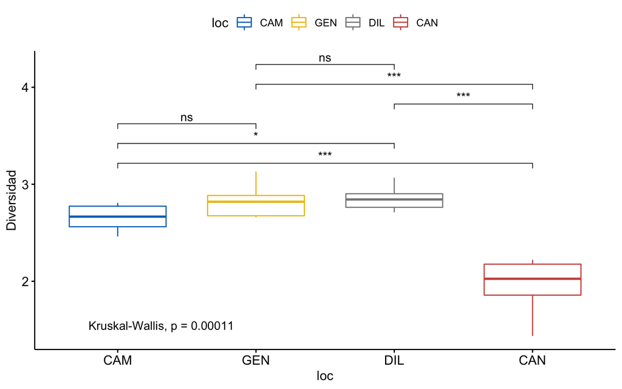

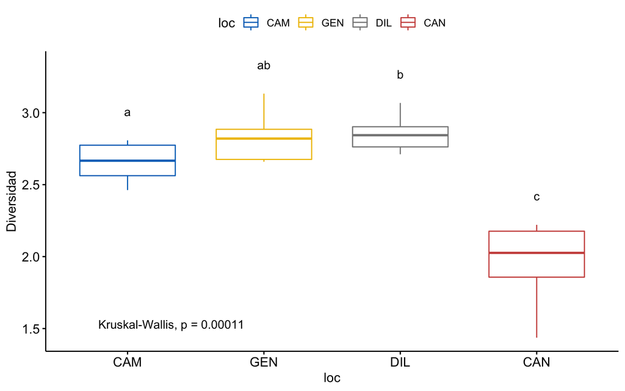

## Análisis de la abundancia total

- Calculamos la abundancia total (ind/10 ha) por sitio para cada año
- Analizamos si existen diferencias para la abundancia total entre sitios (Kruskal-Wallis) y hacemos comparaciones entre sitios (Dunn test)

[output not shown]

<sup>*1*</sup> Statistics presented: mean ± se (minimum, maximum)

```r
kruskal.test(ab_ha_total ~ loc, data = densidad_total)
```

```
    Kruskal-Wallis rank sum test

data:  ab_ha_total by loc
Kruskal-Wallis chi-squared = 6.7528, df = 3, p-value = 0.08021
```

.y.

group1

group2

p

p.adj

p.format

p.signif

method

ab_ha_total

CAM

GEN

0.5737374

1.00

0.574

ns

Wilcoxon

ab_ha_total

CAM

DIL

0.1303807

0.52

0.130

ns

Wilcoxon

ab_ha_total

CAM

CAN

0.1948718

0.58

0.195

ns

Wilcoxon

ab_ha_total

GEN

DIL

0.0379176

0.23

0.038

Wilcoxon

ab_ha_total

GEN

CAN

0.0498834

0.25

0.050

Wilcoxon

ab_ha_total

DIL

CAN

0.8784771

1.00

0.878

ns

Wilcoxon

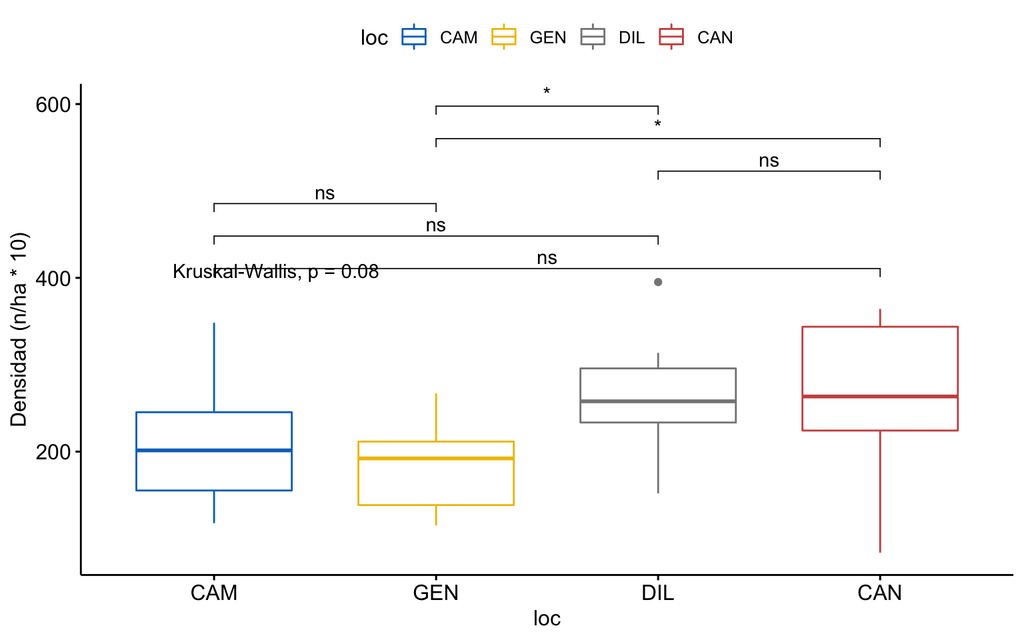

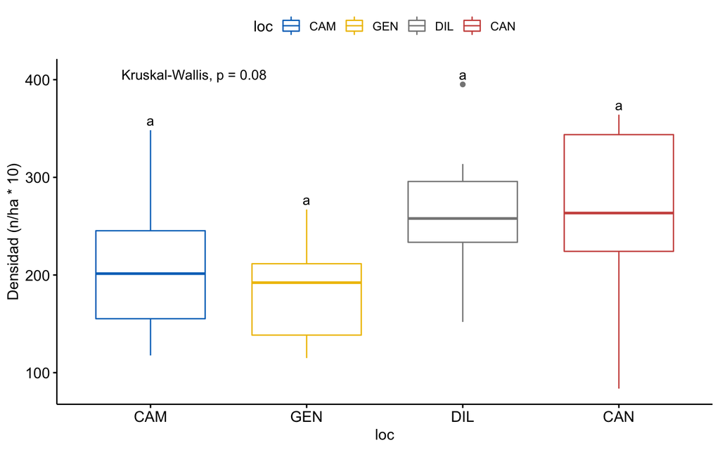

## Riqueza total

| loc | n |
| --- | --- |
| CAM | 55 |
| CAN | 48 |
| DIL | 58 |
| GEN | 59 |

## Indice de dominancia de Simpson

- Calculamos lel índice de dominancia de simpson por sitio para cada año
- Analizamos si existen diferencias para este indice entre sitios (Kruskal-Wallis) y hacemos comparaciones entre sitios (Dunn test)

[output not shown]

<sup>*1*</sup> Statistics presented: mean ± se (minimum, maximum)

```r
kruskal.test(value ~ loc, data = simpson)
```

```
    Kruskal-Wallis rank sum test

data:  value by loc
Kruskal-Wallis chi-squared = 23.753, df = 3, p-value = 2.813e-05
```

.y.

group1

group2

p

p.adj

p.format

p.signif

method

value

CAM

GEN

0.5737374

0.57000

0.57374

ns

Wilcoxon

value

CAM

DIL

0.0003108

0.00093

0.00031

***

Wilcoxon

value

CAM

CAN

0.0001554

0.00093

0.00016

***

Wilcoxon

value

GEN

DIL

0.0206682

0.04100

0.02067

Wilcoxon

value

GEN

CAN

0.0001554

0.00093

0.00016

***

Wilcoxon

value

DIL

CAN

0.0001554

0.00093

0.00016

***

Wilcoxon

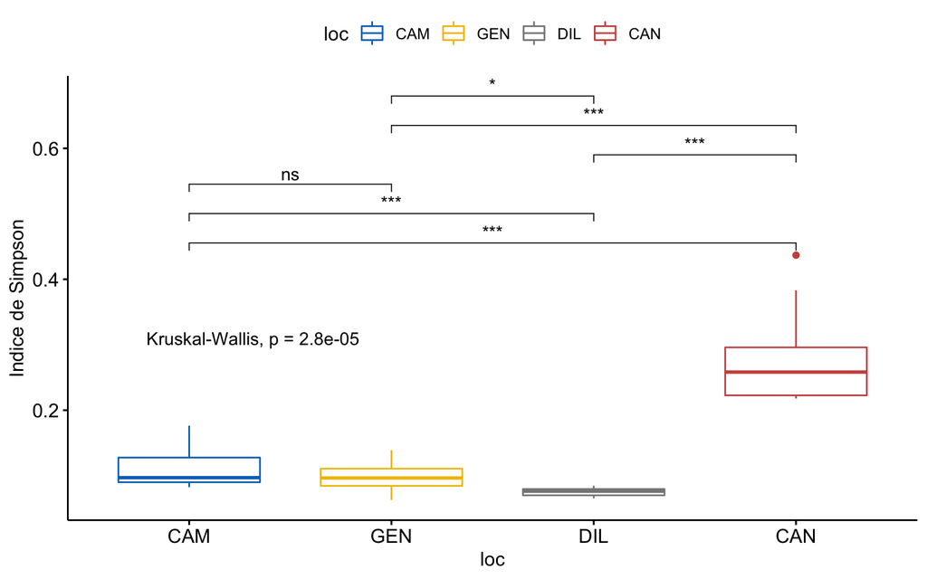

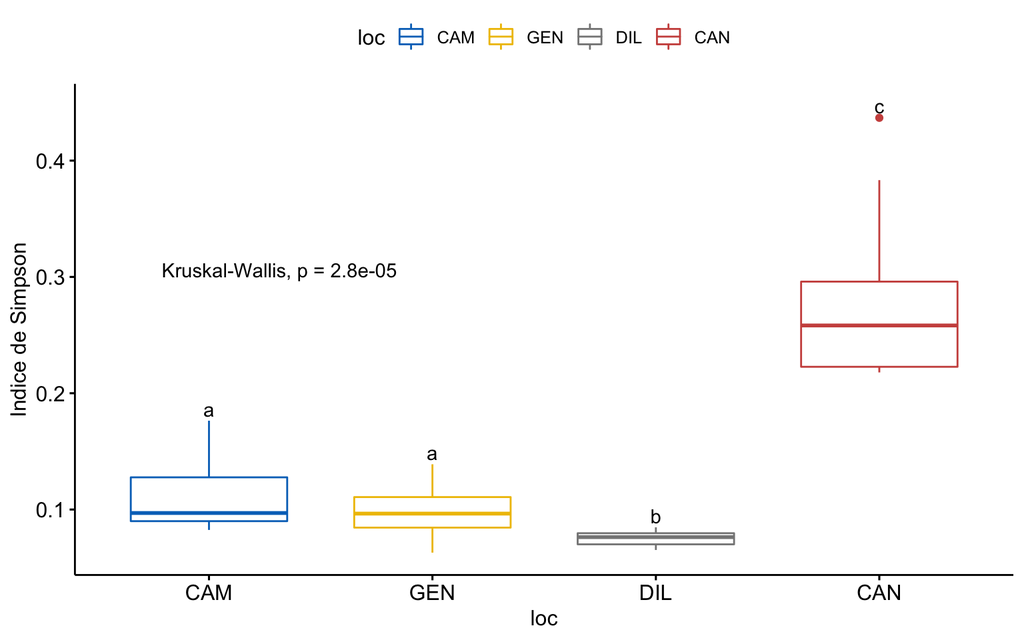

## Indices de disimilaridad

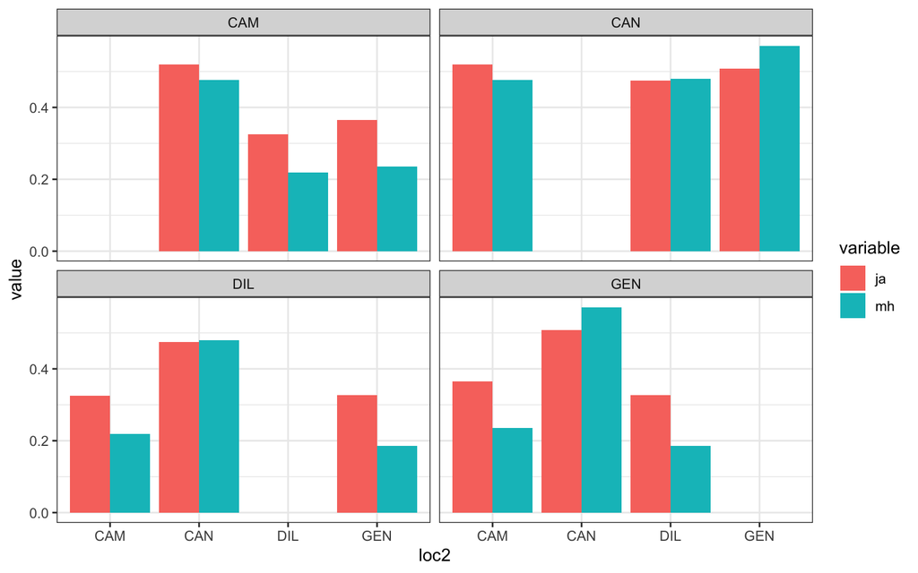

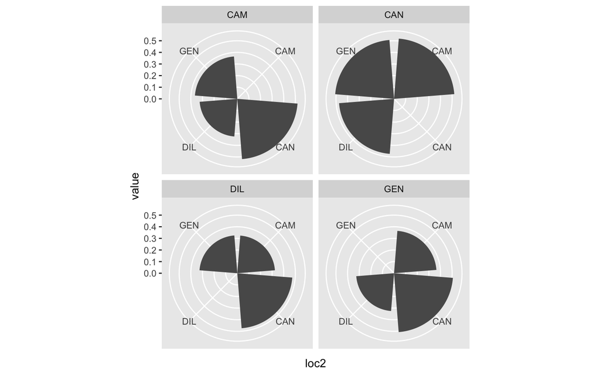

## Analizar diferencias para cada especie entre sitios

Primero analizamos cuantas especies están presentes en mas de un sitio

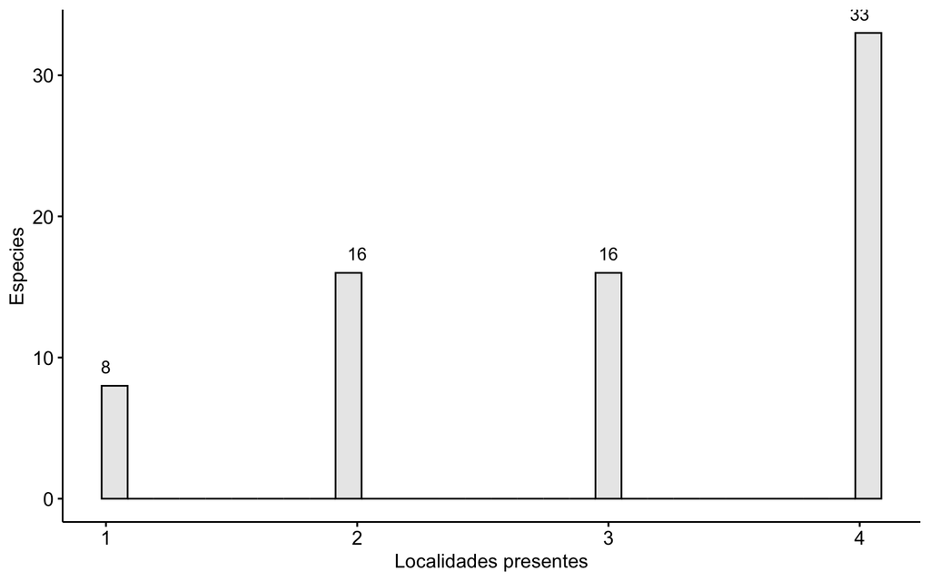

Del total de 73 analizadas encontramos que hay 8 especies que están presentes solo en un sitio.

A continuación se muestran los datos de abundancia ($\text{n ind} \cdot ha^{-1} \cdot 10$). Para cada especie se muestran los valores medios (con su error estandar) para cada población. Además se analiza para cada especie si existen diferencias entre las poblaciones (Kruskal Wallis) y posteriormente se analizan diferencias entre sitios (comparaciones múltiples, *posthoc*, usando test no paramétricos de Wilcoxon). Las diferentes letras indican para una especie diferencias entre localidades.

|  | sp | statistic | p.value | parameter | CAM | CAN | GEN | DIL |
| --- | --- | --- | --- | --- | --- | --- | --- | --- |
| 1 | Acanthis.cannabina | 0.27 | 0.8747 | 2 | 0.267 ± 0.188 a | 0.538 ± 0.538 a | 0.287 ± 0.191 a |  |
| 2 | Aegithalos.caudatus | 18.99 | 0.0003 | 3 | 16.71 ± 2.191 a | 2.591 ± 0.902 b | 7.884 ± 1.441 bc | 12.189 ± 1.94 ac |
| 3 | Anthus | 0.02 | 0.9925 | 2 |  | 0.049 ± 0.049 a | 0.123 ± 0.123 a | 0.196 ± 0.196 a |
| 4 | Anthus.campestris | 0.8 | 0.3698 | 1 |  | 0.342 ± 0.342 a | 0.493 ± 0.291 a |  |
| 5 | Caprimulgus.europaeus | 0.38 | 0.5377 | 1 |  | 0.196 ± 0.148 a |  | 0.049 ± 0.049 a |
| 6 | Carduelis.cannabina | 3.22 | 0.3586 | 3 | 0.401 ± 0.171 a | 0.098 ± 0.064 a | 0.287 ± 0.244 a | 0.049 ± 0.049 a |
| 7 | Carduelis.carduelis | 0.79 | 0.6722 | 2 | 1.649 ± 1.29 a |  | 0.78 ± 0.367 a | 0.294 ± 0.098 a |
| 8 | Carduelis.chloris | 4.95 | 0.0843 | 2 | 1.693 ± 0.659 a |  | 0.944 ± 0.514 a | 0.196 ± 0.196 a |
| 9 | Carduelis.spinus | 0.41 | 0.5232 | 1 |  |  | 0.944 ± 0.625 a | 6.021 ± 5.269 a |
| 10 | Certhia.brachydactyla | 5.31 | 0.1503 | 3 | 7.486 ± 1.955 a | 7.334 ± 1.459 a | 4.435 ± 0.516 a | 7.294 ± 0.844 a |

[output cut: 63 more lines]